# Latent Transition Analaysis

Labs created by Adam Garber & Dina Arch, taken from Nylund et al. (2022)

Updated: April 30, 2025

`University of California, Santa Barbara`

To install package {`rhdf5`}

```r
if (!requireNamespace("BiocManager", quietly = TRUE))
  install.packages("BiocManager")

BiocManager::install("rhdf5")
```

Load packages

```r
library(MplusAutomation)
library(rhdf5)
library(tidyverse)
library(here)
library(glue)
library(janitor)
library(gt)
library(reshape2)
library(cowplot)
#library(PNWColors)
library(ggrepel)
library(haven)
library(modelsummary)
library(corrplot)
library(DiagrammeR)
library(filesstrings)
```

```r
lsay_data <- read_csv(here("data","lsay_lta.csv"), na = c("9999")) %>%
    mutate(across(everything(), as.numeric))
```

# Latent Transition Analysis

[interactive chart not shown]

## Descriptive Statistics

### Data Summary

```r
data <- lsay_data

select_data <- data %>%
 select(female, minority, ab39m:ga33l)

f <- All(select_data) ~ Mean + SD + Min + Median + Max + Histogram
datasummary(f, data, output="markdown")
```

|  | Mean | SD | Min | Median | Max | Histogram |
| --- | --- | --- | --- | --- | --- | --- |
| female | 0.48 | 0.50 | 0.00 | 0.00 | 1.00 | ▇▆ |
| minority | 0.23 | 0.42 | 0.00 | 0.00 | 1.00 | ▇▂ |
| ab39m | 0.61 | 0.49 | 0.00 | 1.00 | 1.00 | ▄▇ |
| ab39t | 0.40 | 0.49 | 0.00 | 0.00 | 1.00 | ▇▅ |
| ab39u | 0.49 | 0.50 | 0.00 | 0.00 | 1.00 | ▇▇ |
| ab39w | 0.40 | 0.49 | 0.00 | 0.00 | 1.00 | ▇▅ |
| ab39x | 0.46 | 0.50 | 0.00 | 0.00 | 1.00 | ▇▆ |
| ga33a | 0.58 | 0.49 | 0.00 | 1.00 | 1.00 | ▅▇ |
| ga33h | 0.43 | 0.49 | 0.00 | 0.00 | 1.00 | ▇▅ |
| ga33i | 0.51 | 0.50 | 0.00 | 1.00 | 1.00 | ▇▇ |
| ga33k | 0.42 | 0.49 | 0.00 | 0.00 | 1.00 | ▇▅ |
| ga33l | 0.42 | 0.49 | 0.00 | 0.00 | 1.00 | ▇▅ |

### Correlation Table

```r
select_data %>%
  datasummary_correlation(output = "markdown")
```

|  | female | minority | ab39m | ab39t | ab39u | ab39w | ab39x | ga33a | ga33h | ga33i | ga33k | ga33l |
| --- | --- | --- | --- | --- | --- | --- | --- | --- | --- | --- | --- | --- |
| female | 1 | . | . | . | . | . | . | . | . | . | . | . |
| minority | -.01 | 1 | . | . | . | . | . | . | . | . | . | . |
| ab39m | -.06 | -.01 | 1 | . | . | . | . | . | . | . | . | . |
| ab39t | -.09 | .05 | .30 | 1 | . | . | . | . | . | . | . | . |
| ab39u | -.11 | .03 | .30 | .48 | 1 | . | . | . | . | . | . | . |
| ab39w | -.11 | .06 | .27 | .46 | .40 | 1 | . | . | . | . | . | . |
| ab39x | -.11 | .05 | .33 | .45 | .41 | .52 | 1 | . | . | . | . | . |
| ga33a | -.05 | .04 | .19 | .11 | .13 | .13 | .15 | 1 | . | . | . | . |
| ga33h | -.06 | .04 | .10 | .15 | .16 | .16 | .20 | .40 | 1 | . | . | . |
| ga33i | -.04 | .02 | .15 | .13 | .18 | .15 | .16 | .40 | .57 | 1 | . | . |
| ga33k | -.07 | .04 | .13 | .15 | .15 | .20 | .18 | .39 | .54 | .48 | 1 | . |
| ga33l | -.04 | .05 | .15 | .15 | .14 | .18 | .23 | .44 | .56 | .49 | .62 | 1 |

### Correlation Plot

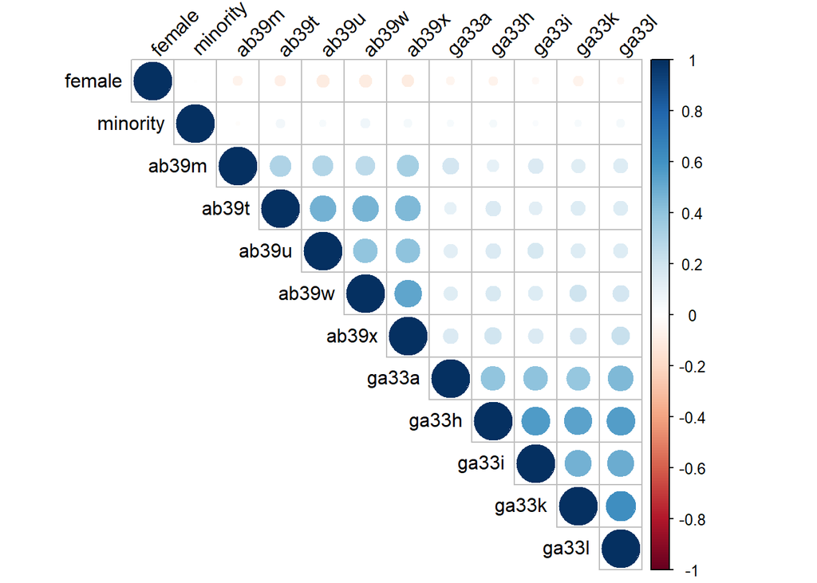

```r
f_cor <- data %>%
 select(female, minority, ab39m:ga33l) %>%
  cor(use = "pairwise.complete.obs")

corrplot(f_cor,
         method = "circle",
         type = "upper",
         tl.col="black",
         tl.srt=45)
```

# Enumeration

## Enumerate Time Point 1 (7th grade)

```r
# NOTE CHANGE: '1:6' indicates the number of k-class models to estimate
# User can change this number to fit research context
# In this example, the code loops or iterates over values 1 through 6 ( '{k}' )
#
t1_enum_k_16  <- lapply(1:6, function(k) {
  enum_t1  <- mplusObject(

# The 'glue' function inserts R code within a string or "quoted green text" using the syntax {---}
#
    TITLE = glue("Class-{k}_Time1"),

    VARIABLE = glue(
    "!!! NOTE CHANGE: List of the five 7th grade science attitude indicators !!!
     categorical = ab39m-ab39x;
          usevar = ab39m-ab39x;

     classes = c({k});"),

  ANALYSIS =
   "estimator = mlr;
    type = mixture;
    !!! NOTE CHANGE: The intial and final start values. Reduce to speed up estimation time. !!!
    starts = 500 100;
    processors=10;",

  OUTPUT = "sampstat residual tech11 tech14;",

  PLOT =
    "type = plot3;
    series = ab39m-ab39x(*);",

  usevariables = colnames(lsay_data),
  rdata = lsay_data)

# NOTE CHANGE: Fix to match appropriate sub-folder name
# See after `here` function (e.g., "enum_LCA_time1")
enum_t1_fit <- mplusModeler(enum_t1,
                 dataout=here("enum_LCA_time1", "t1.dat"),
                 modelout=glue(here("enum_LCA_time1", "c{k}_lca_enum_time1.inp")),
                 check=TRUE, run = TRUE, hashfilename = FALSE)
})
```

**NOTE:** It is highly recommended that you check the output (`.out`) files to check for convergence warnings or syntax errors.

## Enumerate Time Point 2 (10th grade)

```r
t2_enum_k_16  <- lapply(1:6, function(k) {
  enum_t2  <- mplusObject(

    TITLE = glue("Class-{k}_Time2"),

    VARIABLE =
  glue(
    "!!! NOTE CHANGE: List of the five 10th grade science attitude indicators !!!
     categorical = ga33a-ga33l;
          usevar = ga33a-ga33l;

     classes = c({k});"),

  ANALYSIS =
   "estimator = mlr;
    type = mixture;
    starts = 500 100;
    processors=10;",

  OUTPUT = "sampstat residual tech11 tech14;",

  PLOT =
    "type = plot3;
    series = ga33a-ga33l(*);",

  usevariables = colnames(lsay_data),
  rdata = lsay_data)

enum_t2_fit <- mplusModeler(enum_t2,
                 dataout=here("enum_LCA_time2", "t2.dat"),
                 modelout=glue(here("enum_LCA_time2", "c{k}_lca_enum_time2.inp")),
                 check=TRUE, run = TRUE, hashfilename = FALSE)
})
```

# Create Model Fit Summary Table

Read all models for enumeration table

```r
output_enum_t1 <- readModels(here("enum_LCA_time1"), quiet = TRUE)
output_enum_t2 <- readModels(here("enum_LCA_time2"), quiet = TRUE)
```

Extract model fit data

```r
enum_extract1 <- LatexSummaryTable(output_enum_t1,
                keepCols=c("Title", "Parameters", "LL", "BIC", "aBIC",
                           "BLRT_PValue", "T11_VLMR_PValue","Observations"))

enum_extract2 <- LatexSummaryTable(output_enum_t2,
                keepCols=c("Title", "Parameters", "LL", "BIC", "aBIC",
                           "BLRT_PValue", "T11_VLMR_PValue","Observations"))
```

## Calculate Indices Derived from the Log Likelihood (LL)

```r
allFit1 <- enum_extract1 %>%
  mutate(aBIC = -2*LL+Parameters*log((Observations+2)/24)) %>%
  mutate(CAIC = -2*LL+Parameters*(log(Observations)+1)) %>%
  mutate(AWE = -2*LL+2*Parameters*(log(Observations)+1.5)) %>%
  mutate(SIC = -.5*BIC) %>%
  mutate(expSIC = exp(SIC - max(SIC))) %>%
  mutate(BF = exp(SIC-lead(SIC))) %>%
  mutate(cmPk = expSIC/sum(expSIC)) %>%
  select(1:5,9:10,6:7,13,14) %>%
  arrange(Parameters)

allFit2 <- enum_extract2 %>%
  mutate(aBIC = -2*LL+Parameters*log((Observations+2)/24)) %>%
  mutate(CAIC = -2*LL+Parameters*(log(Observations)+1)) %>%
  mutate(AWE = -2*LL+2*Parameters*(log(Observations)+1.5)) %>%
  mutate(SIC = -.5*BIC) %>%
  mutate(expSIC = exp(SIC - max(SIC))) %>%
  mutate(BF = exp(SIC-lead(SIC))) %>%
  mutate(cmPk = expSIC/sum(expSIC)) %>%
  select(1:5,9:10,6:7,13,14) %>%
  arrange(Parameters)

allFit <- full_join(allFit1,allFit2)
```

## Format Fit Table

```r
rows_m1 <- 1:6
rows_m2 <- 7:12


allFit %>%
  mutate(Title = str_remove(Title, "_Time*")) %>%
  gt() %>%
  tab_header(
    title = md("**Model Fit Summary Table**")) %>%
  cols_label(
    Title = "Classes",
    Parameters = md("Par"),
    LL = md("*LL*"),
    T11_VLMR_PValue = "VLMR",
    BLRT_PValue = "BLRT",
    BF = md("BF"),
    cmPk = md("*cmP_k*")) %>%
  tab_footnote(
    footnote = md(
    "*Note.* Par = Parameters; *LL* = model log likelihood;
      BIC = Bayesian information criterion;
      aBIC = sample size adjusted BIC; CAIC = consistent Akaike information criterion;
      AWE = approximate weight of evidence criterion;
      BLRT = bootstrapped likelihood ratio test p-value;
      VLMR = Vuong-Lo-Mendell-Rubin adjusted likelihood ratio test p-value;
      cmPk = approximate correct model probability."),
    locations = cells_title()) %>%
  tab_options(column_labels.font.weight = "bold") %>%
  fmt_number(10,decimals = 2,
             drop_trailing_zeros=TRUE,
             suffixing = TRUE) %>%
  fmt_number(c(3:9,11),
             decimals = 2) %>%
  fmt_missing(1:11,
              missing_text = "--") %>%
  fmt(c(8:9,11),
    fns = function(x)
    ifelse(x<0.001, "<.001",
           scales::number(x, accuracy = 0.01))) %>%
  fmt(10, fns = function(x)
    ifelse(x>100, ">100",
           scales::number(x, accuracy = .1))) %>%
  tab_row_group(
    group = "Time-1",
    rows = 1:6) %>%
  tab_row_group(
    group = "Time-2",
    rows = 7:12) %>%
  row_group_order(
      groups = c("Time-1","Time-2")
      ) %>%
   tab_style(
    style = list(
      cell_text(weight = "bold")
      ),
    locations = list(cells_body(
     columns = BIC,
     row = BIC == min(BIC[rows_m1]) # Model 1
    ),
    cells_body(
     columns = aBIC,
     row = aBIC == min(aBIC[rows_m1])
    ),
    cells_body(
     columns = CAIC,
     row = CAIC == min(CAIC[rows_m1])
    ),
    cells_body(
     columns = AWE,
     row = AWE == min(AWE[rows_m1])
    ),
    cells_body(
     columns = cmPk,
     row =  cmPk == max(cmPk[rows_m1])
     ),
    cells_body(
     columns = BIC,
     row = BIC == min(BIC[rows_m2]) # Model 2
    ),
    cells_body(
     columns = aBIC,
     row = aBIC == min(aBIC[rows_m2])
    ),
    cells_body(
     columns = CAIC,
     row = CAIC == min(CAIC[rows_m2])
    ),
    cells_body(
     columns = AWE,
     row = AWE == min(AWE[rows_m2])
    ),
    cells_body(
     columns = cmPk,
     row =  cmPk == max(cmPk[rows_m2])
     ),
    cells_body(
     columns = BF,
     row =  BF > 10),
    cells_body(
     columns =  BLRT_PValue,
     row =  ifelse(BLRT_PValue < .05 & lead(BLRT_PValue) > .05, BLRT_PValue < .05, NA)),
    cells_body(
     columns =  T11_VLMR_PValue,
     row =  ifelse(T11_VLMR_PValue < .05 & lead(T11_VLMR_PValue) > .05, T11_VLMR_PValue < .05, NA))
  )
)
```

**Model Fit Summary Table**<sup>1</sup>

| Classes | Par | *LL* | BIC | aBIC | CAIC | AWE | BLRT | VLMR | BF | *cmP_k* |
| --- | --- | --- | --- | --- | --- | --- | --- | --- | --- | --- |
| Time-1 |  |  |  |  |  |  |  |  |  |  |
| Class-11 | 5 | −10,250.60 | 20,541.34 | 20,525.45 | 20,546.34 | 20,596.47 | – | – | 0.0 | <.001 |
| Class-21 | 11 | −8,785.32 | 17,658.92 | 17,623.97 | 17,669.93 | 17,780.22 | <.001 | <.001 | 0.0 | <.001 |
| Class-31 | 17 | −8,693.57 | 17,523.59 | 17,469.57 | 17,540.59 | 17,711.04 | <.001 | <.001 | 0.0 | 0.00 |
| Class-41 | 23 | −8,664.09 | 17,512.79 | 17,439.71 | 17,535.79 | 17,766.40 | <.001 | <.001 | >100 | 1.00 |
| Class-51 | 29 | −8,662.39 | 17,557.54 | 17,465.40 | 17,586.54 | 17,877.31 | 1.00 | 0.67 | >100 | <.001 |
| Class-61 | 35 | −8,661.54 | 17,604.01 | 17,492.80 | 17,639.01 | 17,989.94 | 0.67 | 0.93 | – | <.001 |
| Time-2 |  |  |  |  |  |  |  |  |  |  |
| Class-12 | 5 | −7,658.79 | 15,356.19 | 15,340.30 | 15,361.19 | 15,409.80 | – | – | 0.0 | <.001 |
| Class-22 | 11 | −6,073.81 | 12,232.56 | 12,197.61 | 12,243.56 | 12,350.50 | <.001 | <.001 | 0.0 | <.001 |
| Class-32 | 17 | −5,988.36 | 12,107.99 | 12,053.98 | 12,124.99 | 12,290.27 | <.001 | <.001 | 0.5 | 0.32 |
| Class-42 | 23 | −5,964.45 | 12,106.50 | 12,033.43 | 12,129.51 | 12,353.12 | <.001 | 0.00 | >100 | 0.68 |
| Class-52 | 29 | −5,961.68 | 12,147.30 | 12,055.16 | 12,176.30 | 12,458.25 | 0.31 | 0.36 | >100 | <.001 |
| Class-62 | 35 | −5,961.26 | 12,192.79 | 12,081.59 | 12,227.79 | 12,568.07 | 1.00 | 0.57 | – | <.001 |

<sup>1</sup> *Note.* Par = Parameters; *LL* = model log likelihood; BIC = Bayesian information criterion; aBIC = sample size adjusted BIC; CAIC = consistent Akaike information criterion; AWE = approximate weight of evidence criterion; BLRT = bootstrapped likelihood ratio test p-value; VLMR = Vuong-Lo-Mendell-Rubin adjusted likelihood ratio test p-value; cmPk = approximate correct model probability.

## Compare Time 1 & Time 2 LCA Plots

Read models for plotting (4-class models)

```r
model_t1_c4 <- readModels(here("enum_LCA_time1", "c4_lca_enum_time1.out"), quiet = TRUE)
model_t2_c4 <- readModels(here("enum_LCA_time2", "c4_lca_enum_time2.out"), quiet = TRUE)
```

### Create a function `plot_lca_function` that requires 5 arguments:

- `model_name`: name of Mplus model object (e.g., `model_t1_c4`)
- `item_num`: the number of items in LCA measurement model (e.g., `5`)
- `class_num`: the number of classes (*k*) in LCA model (e.g., `4`)
- `item_labels`: the item labels for x-axis (e.g., `c("Enjoy","Useful","Logical","Job","Adult")`)
- `plot_title`: include the title of the plot here (e.g., `"Time 1 LCA Conditional Item Probability Plot"`)

```r
plot_lca_function <- function(model_name,item_num,class_num,item_labels,plot_title){

mplus_model <- as.data.frame(model_name$gh5$means_and_variances_data$estimated_probs$values)
plot_t1 <- mplus_model[seq(2, 2*item_num, 2),]

c_size <- as.data.frame(model_name$class_counts$modelEstimated$proportion)
colnames(c_size) <- paste0("cs")
c_size <- c_size %>% mutate(cs = round(cs*100, 2))
colnames(plot_t1) <- paste0("C", 1:class_num, glue(" ({c_size[1:class_num,]}%)"))

plot_t1 <- cbind(Var = paste0("U", 1:item_num), plot_t1)
plot_t1$Var <- factor(plot_t1$Var,
               labels = item_labels)
plot_t1$Var <- fct_inorder(plot_t1$Var)
pd_long_t1 <- melt(plot_t1, id.vars = "Var")

p <- pd_long_t1 %>%
  ggplot(aes(x = as.integer(Var), y = value,
  shape = variable, colour = variable, lty = variable)) +
  geom_point(size = 4) + geom_line() +
  scale_x_continuous("", breaks = 1:5, labels = plot_t1$Var) +
  scale_colour_grey() +
  labs(title = plot_title, y = "Probability") +
  theme_cowplot() +
  theme(legend.title = element_blank(),
        legend.position = "top")

p
return(p)
}
```

### Time 1 LCA - Conditional Item Probability Plot

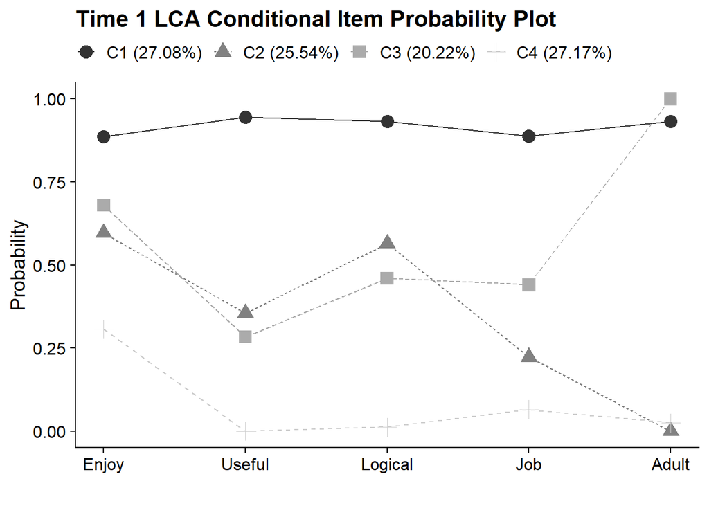

```r
plot_lca_function(
  model_name = model_t1_c4,
  item_num = 5,
  class_num = 4,
  item_labels = c("Enjoy","Useful","Logical","Job","Adult"),
  plot_title = "Time 1 LCA Conditional Item Probability Plot"
  )
```

```r
ggsave(here("figures", "T1_C4_LCA_plot.png"), dpi=300, height=5, width=7, units="in")
```

### Time 2 LCA - Conditional Item Probability Plot

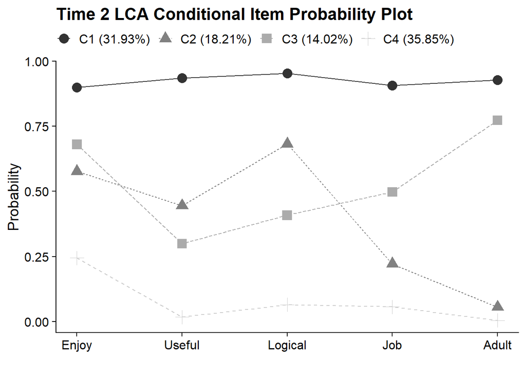

```r
plot_lca_function(
  model_name = model_t2_c4,
  item_num = 5,
  class_num = 4,
  item_labels = c("Enjoy","Useful","Logical","Job","Adult"),
  plot_title = "Time 2 LCA Conditional Item Probability Plot"
  )
```

```r
ggsave(here("figures", "T2_C4_LCA_plot.png"), dpi=300, height=5, width=7, units="in")
```

# Estimate Latent Transition Analysis (LTA) Model

## Estimate Invariant LTA Model

```r
lta_inv <- mplusObject(

  TITLE =
    "Invariant LTA",

  VARIABLE =
     "usev = ab39m ab39t ab39u ab39w ab39x  ! 7th grade indicators
             ga33a ga33h ga33i ga33k ga33l; ! 10th grade indicators

      categorical = ab39m-ab39x ga33a-ga33l;

      classes = c1(4) c2(4);",

  ANALYSIS =
     "estimator = mlr;
      type = mixture;
      starts = 500 100;
      processors=10;",

  MODEL =
     "%overall%
      c2 on c1;

      MODEL c1:
      %c1#1%
      [AB39M$1-AB39X$1] (1-5);  !!! labels that are repeated will constrain parameters to equality !!!
      %c1#2%
      [AB39M$1-AB39X$1] (6-10);
      %c1#3%
      [AB39M$1-AB39X$1] (11-15);
      %c1#4%
      [AB39M$1-AB39X$1] (16-20);

      MODEL c2:
      %c2#1%
      [GA33A$1-GA33L$1] (1-5);
      %c2#2%
      [GA33A$1-GA33L$1] (6-10);
      %c2#3%
      [GA33A$1-GA33L$1] (11-15);
      %c2#4%
      [GA33A$1-GA33L$1] (16-20);",

  SAVEDATA =
   "file = LTA_Inv_CPROBS.dat;
    save = cprob;
    missflag = 9999;",

  OUTPUT = "tech1 tech15 svalues;",

  usevariables = colnames(lsay_data),
  rdata = lsay_data)

lta_inv_fit <- mplusModeler(lta_inv,
                 dataout=here("LTA_models", "lta.dat"),
                 modelout=here("LTA_models", "4-class-invariant.inp"),
                 check=TRUE, run = TRUE, hashfilename = FALSE)
```

## Estimate Non-Invariant Estimated LTA Model

```r
lta_non_inv <- mplusObject(

  TITLE =
    "Non-Invariant LTA",

  VARIABLE =
     "usev = ab39m ab39t ab39u ab39w ab39x  ! 7th grade indicators
             ga33a ga33h ga33i ga33k ga33l; ! 10th grade indicators

      categorical = ab39m-ab39x ga33a-ga33l;

      classes = c1(4) c2(4);",

  ANALYSIS =
     "estimator = mlr;
      type = mixture;
      starts = 500 100;
      processors=10;",

  MODEL =
     "%overall%
      c2 on c1; !!! estimate all multinomial logistic regressions !!!

      !!! The above syntax can also be written as: !!!
               ! c2#1 on c1#1 c1#2 c1#3; !
               ! c2#2 on c1#1 c1#2 c1#3; !
               ! c2#3 on c1#1 c1#2 c1#3; !

      MODEL c1: !!! the following syntax will allow item thresholds to be estimated for each class (e.g. noninvariance) !!!

      %c1#1%
      [AB39M$1-AB39X$1];
      %c1#2%
      [AB39M$1-AB39X$1];
      %c1#3%
      [AB39M$1-AB39X$1];
      %c1#4%
      [AB39M$1-AB39X$1];

      MODEL c2:
      %c2#1%
      [GA33A$1-GA33L$1];
      %c2#2%
      [GA33A$1-GA33L$1];
      %c2#3%
      [GA33A$1-GA33L$1];
      %c2#4%
      [GA33A$1-GA33L$1];",

  OUTPUT = "tech1 tech15 svalues;",

  usevariables = colnames(lsay_data),
  rdata = lsay_data)

lta_non_inv_fit <- mplusModeler(lta_non_inv,
                     dataout=here("LTA_models", "lta.dat"),
                     modelout=here("LTA_models", "4-class-non-invariant.inp"),
                     check=TRUE, run = TRUE, hashfilename = FALSE)
```

## Conduct Sattorra-Bentler adjusted Log Likelihood Ratio Difference Testing

- non-invariant (comparison): This model has **more** parameters.
- invariant (nested): This model has **less** parameters.

```r
# *0 = null or nested model & *1 = comparison  or parent model

lta_models <- readModels(here("LTA_models"), quiet = TRUE)

# Log Likelihood Values
L0 <- lta_models[["X4.class.invariant.out"]][["summaries"]][["LL"]]
L1 <- lta_models[["X4.class.non.invariant.out"]][["summaries"]][["LL"]]

# LRT equation
lr <- -2*(L0-L1)

# Parameters
p0 <- lta_models[["X4.class.invariant.out"]][["summaries"]][["Parameters"]]
p1 <- lta_models[["X4.class.non.invariant.out"]][["summaries"]][["Parameters"]]

# Scaling Correction Factors
c0 <- lta_models[["X4.class.invariant.out"]][["summaries"]][["LLCorrectionFactor"]]
c1 <- lta_models[["X4.class.non.invariant.out"]][["summaries"]][["LLCorrectionFactor"]]

# Difference Test Scaling correction
cd <- ((p0*c0)-(p1*c1))/(p0-p1)

# Chi-square difference test(TRd)
TRd <- (lr)/(cd)

# Degrees of freedom
df <- abs(p0 - p1)


# Significance test
(p_diff <- pchisq(TRd, df, lower.tail=FALSE))
```

```
## [1] 0.6245173
```

[Reference](https://stats.idre.ucla.edu/mplus/faq/how-can-i-compute-a-chi-square-test-for-nested-models-with-the-mlr-or-mlm-estimators/)

Alternate, less verbose way to run LTA with the `createMixtures` function.

```r
data <- lsay_data %>% select(5:14) # select only the indicator variables

createMixtures(
classes = 4,
filename_stem = "sci_attitude",
model_overall = "c2 ON c1;",
model_class_specific = c(
"[ab39m$1] (a{C});  [ab39t$1] (b{C});  [ab39u$1] (c{C});  [ab39w$1] (d{C});  [ab39x$1] (e{C});",
"[ga33a$1] (a{C});  [ga33h$1] (b{C});  [ga33i$1] (c{C});  [ga33k$1] (d{C});  [ga33l$1] (e{C});"),
rdata = data,
ANALYSIS = "PROCESSORS IS 10; STARTS = 500 100; PARAMETERIZATION = PROBABILITY;",
VARIABLE = "CATEGORICAL = ab39m-ab39x ga33a-ga33l;")

#runModels(filefilter = "sci_attitude")

# Move files to folder
files <- list.files(here(), pattern = "sci_attitude")
move_files(files, here("LTA_models"), overwrite = TRUE)

results <- readModels(filefilter = "sci_attitude")
```

Read invariance model and extract parameters (intercepts and multinomial regression coefficients)

```r
lta_inv1 <- readModels(here("LTA_models","4-Class-Invariant.out" ), quiet = TRUE)

par <- as_tibble(lta_inv1[["parameters"]][["unstandardized"]]) %>%
  select(1:3) %>%
  filter(grepl('ON|Means', paramHeader)) %>%
  mutate(est = as.numeric(est))
```

Manual method to calculate transition probabilities:

Although possible to extract transition probabilities directly from the output the following code illustrates how the parameters are used to calculate each transition. This is useful for conducting advanced LTA model specifications such as making specific constraints within or between transition matrices, or testing the equivalence of specific transition probabilities.

```r
# Name each parameter individually to make the subsequent calculations more readable
a1 <- unlist(par[13,3]); a2 <- unlist(par[14,3]); a3 <- unlist(par[15,3]); b11 <- unlist(par[1,3]);
b21 <- unlist(par[4,3]); b31 <- unlist(par[7,3]); b12 <- unlist(par[2,3]); b22 <- unlist(par[5,3]);
b32 <- unlist(par[8,3]); b13 <- unlist(par[3,3]); b23 <- unlist(par[6,3]); b33 <- unlist(par[9,3])

# Calculate transition probabilities from the logit parameters
t11 <- exp(a1+b11)/(exp(a1+b11)+exp(a2+b21)+exp(a3+b31)+exp(0))
t12 <- exp(a2+b21)/(exp(a1+b11)+exp(a2+b21)+exp(a3+b31)+exp(0))
t13 <- exp(a3+b31)/(exp(a1+b11)+exp(a2+b21)+exp(a3+b31)+exp(0))
t14 <- 1 - (t11 + t12 + t13)

t21 <- exp(a1+b12)/(exp(a1+b12)+exp(a2+b22)+exp(a3+b32)+exp(0))
t22 <- exp(a2+b22)/(exp(a1+b12)+exp(a2+b22)+exp(a3+b32)+exp(0))
t23 <- exp(a3+b32)/(exp(a1+b12)+exp(a2+b22)+exp(a3+b32)+exp(0))
t24 <- 1 - (t21 + t22 + t23)

t31 <- exp(a1+b13)/(exp(a1+b13)+exp(a2+b23)+exp(a3+b33)+exp(0))
t32 <- exp(a2+b23)/(exp(a1+b13)+exp(a2+b23)+exp(a3+b33)+exp(0))
t33 <- exp(a3+b33)/(exp(a1+b13)+exp(a2+b23)+exp(a3+b33)+exp(0))
t34 <- 1 - (t31 + t32 + t33)

t41 <- exp(a1)/(exp(a1)+exp(a2)+exp(a3)+exp(0))
t42 <- exp(a2)/(exp(a1)+exp(a2)+exp(a3)+exp(0))
t43 <- exp(a3)/(exp(a1)+exp(a2)+exp(a3)+exp(0))
t44 <- 1 - (t41 + t42 + t43)
```

## Create Transition Table

```r
t_matrix <- tibble(
  "Time1" = c("C1=Anti-Science","C1=Amb. w/ Elevated","C1=Amb. w/ Minimal","C1=Pro-Science"),
  "C2=Anti-Science" = c(t11,t21,t31,t41),
  "C2=Amb. w/ Elevated" = c(t12,t22,t32,t42),
  "C2=Amb. w/ Minimal" = c(t13,t23,t33,t43),
  "C2=Pro-Science" = c(t14,t24,t34,t44))

t_matrix %>%
  gt(rowname_col = "Time1") %>%
  tab_stubhead(label = "7th grade") %>%
  tab_header(
    title = md("**Student transitions from 7th grade (rows) to 10th grade (columns)**"),
    subtitle = md("&nbsp;")) %>%
  fmt_number(2:5,decimals = 2) %>%
  tab_spanner(label = "10th grade",columns = 2:5) %>%
  tab_footnote(
    footnote = md(
    "*Note.* Transition matrix values are the identical to Table 5, however Table 5
    has the values rearranged by class for interpretation purposes. Classes may be arranged
    directly through Mplus syntax using start values."),
    locations = cells_title())
```

**Student transitions from 7th grade (rows) to 10th grade (columns)**<sup>1</sup>

<sup>1</sup>

| 7th grade | 10th grade C2=Anti-Science | 10th grade C2=Amb. w/ Elevated | 10th grade C2=Amb. w/ Minimal | 10th grade C2=Pro-Science |
| --- | --- | --- | --- | --- |
| C1=Anti-Science | 0.30 | 0.26 | 0.35 | 0.08 |
| C1=Amb. w/ Elevated | 0.12 | 0.52 | 0.21 | 0.15 |
| C1=Amb. w/ Minimal | 0.16 | 0.19 | 0.56 | 0.09 |
| C1=Pro-Science | 0.15 | 0.32 | 0.27 | 0.27 |

# Adding Covariates

We use the ML three-step method to estimate LTA models with predictors and distal outcomes). Estimate the unconditional model for each latent variable with the predictors included in the `auxiliary` option for at least one of the models.

Covariates

- `sci_issues7`: Interest in science issues (1 = Not at all interested, 2 = Moderately Interested, 3 = Very interested)
- `sci_irt7`: 7th Grade Science IRT Score (Continuous)
- `female`: Gender (0 = Male, 1 = Female)

## Step 1 - Estimate Unconditional Model w/ Auxiliary Specification

*7th Grade*

```r
step1  <- mplusObject(
  TITLE = "Step 1 - T1",
  VARIABLE =
  "usevar = ab39m ab39t ab39u ab39w ab39x;
  categorical = ab39m ab39t ab39u ab39w ab39x;

   classes = c(4);

   auxiliary = sci_issues7 sci_irt7 female;

   idvariable = casenum;",

  ANALYSIS =
   "estimator = mlr;
    type = mixture;
    starts = 0;
    optseed = 534483;",

  SAVEDATA =
   "File=3step_t1.dat;
    Save=cprob;",

  OUTPUT = "residual tech11 tech14 svalues",

  PLOT =
    "type = plot3;
    series = ab39m-ab39x(*);",

  usevariables = colnames(lsay_data),
  rdata = lsay_data)

step1_fit <- mplusModeler(step1,
                            dataout=here("cov_lta", "t1.dat"),
                            modelout=here("cov_lta","one_T1.inp") ,
                            check=TRUE, run = TRUE, hashfilename = FALSE)
```

*10th Grade*

```r
step1  <- mplusObject(
  TITLE = "Step 1 - T1",
  VARIABLE =
  "usevar =  ga33a ga33h ga33i ga33k ga33l;
  categorical =  ga33a ga33h ga33i ga33k ga33l;

   classes = c(4);

   !auxiliary = sci_issues7 sci_irt7 female;

   idvariable = casenum;",

  ANALYSIS =
   "estimator = mlr;
    type = mixture;
    starts = 0;
    optseed = 392418;",

  SAVEDATA =
   "File=3step_t2.dat;
    Save=cprob;",

  OUTPUT = "residual tech11 tech14 svalues",

  PLOT =
    "type = plot3;
    series = ga33a-ga33l(*);",

  usevariables = colnames(lsay_data),
  rdata = lsay_data)

step1_fit <- mplusModeler(step1,
                            dataout=here("cov_lta", "t2.dat"),
                            modelout=here("cov_lta","one_T2.inp") ,
                            check=TRUE, run = TRUE, hashfilename = FALSE)
```

Plot Time 1

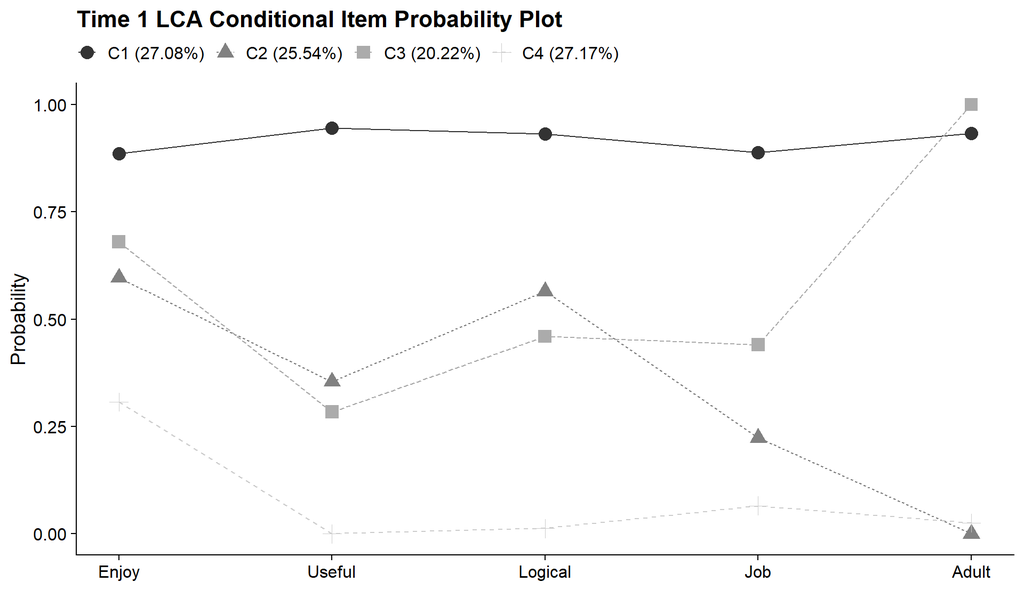

```r
output_T1 <- readModels(here("cov_lta","one_T1.out"))

plot_lca_function(
  model_name = output_T1,
  item_num = 5,
  class_num = 4,
  item_labels = c("Enjoy","Useful","Logical","Job","Adult"),
  plot_title = "Time 1 LCA Conditional Item Probability Plot"
  )
```

Plot Time 2

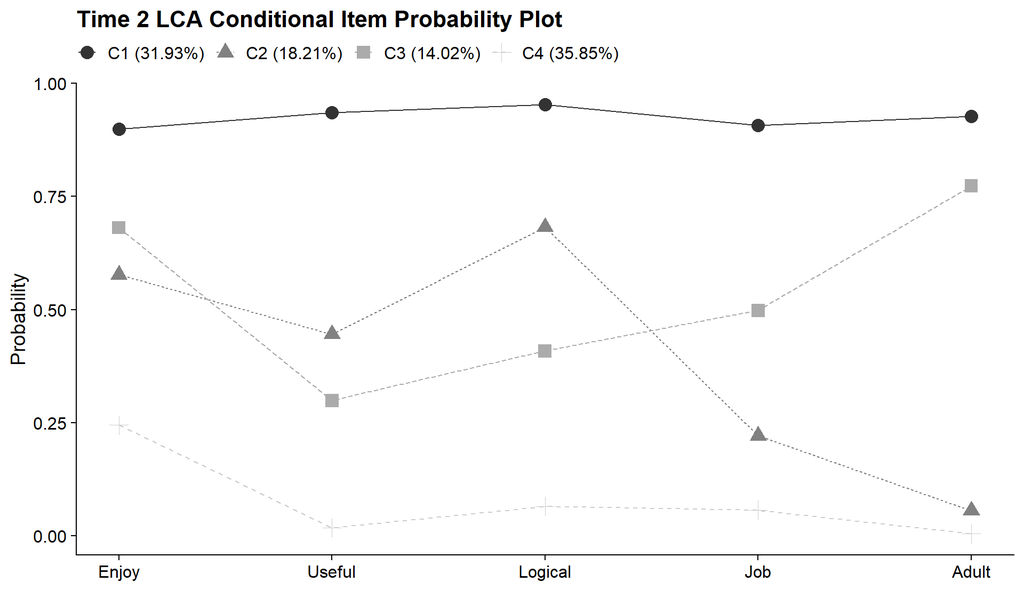

```r
output_T2 <- readModels(here("cov_lta","one_T2.out"))

plot_lca_function(
  model_name = output_T2,
  item_num = 5,
  class_num = 4,
  item_labels = c("Enjoy","Useful","Logical","Job","Adult"),
  plot_title = "Time 2 LCA Conditional Item Probability Plot"
  )
```

## Step 2 - Determine Measurement Error

Extract logits for the classification probabilities for the most likely latent class:

```r
logit_cprobs_T1 <- as.data.frame(output_T1[["class_counts"]]
                                       [["logitProbs.mostLikely"]])

logit_cprobs_T2 <- as.data.frame(output_T2[["class_counts"]]
                                       [["logitProbs.mostLikely"]])
```

Extract saved dataset:

```r
savedata_T1 <- as.data.frame(output_T1[["savedata"]])
savedata_T2 <- as.data.frame(output_T2[["savedata"]])
```

Rename the column in savedata named “C” and change to “N”

```r
colnames(savedata_T1)[colnames(savedata_T1)=="C"] <- "N_T1"
colnames(savedata_T2)[colnames(savedata_T2)=="C"] <- "N_T2"

savedata <- savedata_T1 %>%
  full_join(savedata_T2, by = "CASENUM")
```

## Step 3 - Add Auxiliary Variables

```r
step3  <- mplusObject(
  TITLE = "ML Three Step LTA Model",

  VARIABLE =
 "nominal=N_T1 N_T2;
  usevar = N_T1 N_T2 SCI_IRT7 FEMALE;
  classes = c1(4) c2(4);" ,

  ANALYSIS =
 "estimator = mlr;
  type = mixture;
  starts = 0;",

  MODEL =
  glue(
 " %OVERALL%

   c2 on c1;
   c1 c2 on  SCI_IRT7 FEMALE;

  MODEL c1:

  %c1#1%
  [N_T1#1@{logit_cprobs_T1[1,1]}];
  [N_T1#2@{logit_cprobs_T1[1,2]}];
  [N_T1#3@{logit_cprobs_T1[1,3]}];

  %c1#2%
  [N_T1#1@{logit_cprobs_T1[2,1]}];
  [N_T1#2@{logit_cprobs_T1[2,2]}];
  [N_T1#3@{logit_cprobs_T1[2,3]}];

  %c1#3%
  [N_T1#1@{logit_cprobs_T1[3,1]}];
  [N_T1#2@{logit_cprobs_T1[3,2]}];
  [N_T1#3@{logit_cprobs_T1[3,3]}];

  %c1#4%
  [N_T1#1@{logit_cprobs_T1[4,1]}];
  [N_T1#2@{logit_cprobs_T1[4,2]}];
  [N_T1#3@{logit_cprobs_T1[4,3]}];


  MODEL c2:

  %c2#1%
  [N_T2#1@{logit_cprobs_T2[1,1]}];
  [N_T2#2@{logit_cprobs_T2[1,2]}];
  [N_T2#3@{logit_cprobs_T2[1,3]}];

  %c2#2%
  [N_T2#1@{logit_cprobs_T2[2,1]}];
  [N_T2#2@{logit_cprobs_T2[2,2]}];
  [N_T2#3@{logit_cprobs_T2[2,3]}];


  %c2#3%
  [N_T2#1@{logit_cprobs_T2[3,1]}];
  [N_T2#2@{logit_cprobs_T2[3,2]}];
  [N_T2#3@{logit_cprobs_T2[3,3]}];

   %c2#4%
  [N_T2#1@{logit_cprobs_T2[4,1]}];
  [N_T2#2@{logit_cprobs_T2[4,2]}];
  [N_T2#3@{logit_cprobs_T2[4,3]}];"),


  OUTPUT = "tech15;",

  usevariables = colnames(savedata),
  rdata = savedata)

step3_fit <- mplusModeler(step3,
               dataout=here("cov_lta", "three.dat"),
               modelout=here("cov_lta", "three.inp"),
               check=TRUE, run = TRUE, hashfilename = FALSE)
```

### LTA Transition Plot

**NOTE:** The function found in `plot_transitions_function.R` is specific to a model with 2 time-points and 4-classes & must be updated to accommodate other models.

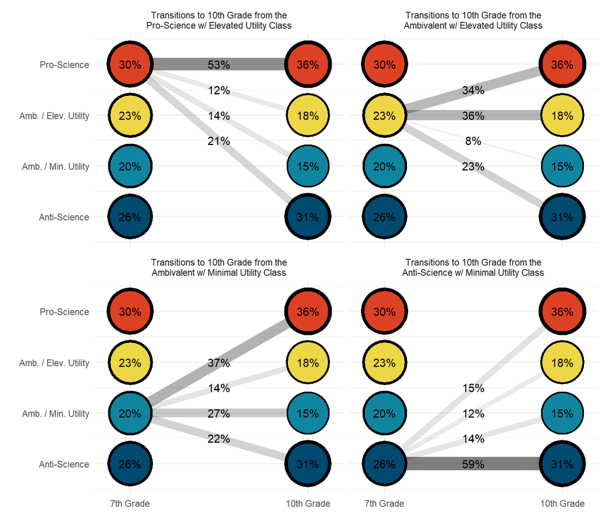

```r
library(PNWColors)
library(ggrepel)

source("plot_transitions_function.R") # Script is located in the project repository

lta_model <- readModels(here("cov_lta", "three.out"))

plot_transitions_function(
  model_name = lta_model,
  color_pallete = pnw_palette("Bay", n=4, type = "discrete"),
  facet_labels =c(
    `1` = "Transitions to 10th Grade from the Pro-Science w/ Elevated Utility Class",
    `2` = "Transitions to 10th Grade from the Ambivalent w/ Elevated Utility Class",
    `3` = "Transitions to 10th Grade from the Ambivalent w/ Minimal Utility Class",
    `4` = "Transitions to 10th Grade from the Anti-Science w/ Minimal Utility Class"),
  timepoint_labels = c('1' = "7th Grade", '2' = "10th Grade"),
  class_labels = c(
    "Pro-Science",
    "Amb. / Elev. Utility",
    "Amb. / Min. Utility",
    "Anti-Science")
  )
```

Table:

```r
lta_prob <- as.data.frame(lta_model$class_counts$transitionProbs$probability)


t_matrix <- tibble(
  "7th Grade" = c("Pro-Science","Amb. / Elev. Utility","Amb. / Min. Utility","Anti-Science"),
  "Pro-Science" = c(lta_prob[1,1],lta_prob[2,1],lta_prob[3,1],lta_prob[4,1]),
  "Amb. / Elev. Utility" = c(lta_prob[5,1],lta_prob[6,1],lta_prob[7,1],lta_prob[8,1]),
  "Amb. / Min. Utility" = c(lta_prob[9,1],lta_prob[10,1],lta_prob[11,1],lta_prob[12,1]),
  "Anti-Science" = c(lta_prob[13,1],lta_prob[14,1],lta_prob[15,1],lta_prob[16,1]))

t_matrix %>%
  gt(rowname_col = "7th Grade") %>%
  tab_stubhead(label = "7th Grade") %>%
  tab_header(
    title = md("**Transition Probabilities**")) %>%
  fmt_number(2:5,decimals = 2) %>%
  tab_spanner(label = "10th Grade",columns = 2:5)#%>%
```

**Transition Probabilities**

| 7th Grade | 10th Grade Pro-Science | 10th Grade Amb. / Elev. Utility | 10th Grade Amb. / Min. Utility | 10th Grade Anti-Science |
| --- | --- | --- | --- | --- |
| Pro-Science | 0.53 | 0.12 | 0.14 | 0.21 |
| Amb. / Elev. Utility | 0.34 | 0.35 | 0.08 | 0.23 |
| Amb. / Min. Utility | 0.37 | 0.14 | 0.27 | 0.22 |
| Anti-Science | 0.15 | 0.12 | 0.14 | 0.59 |

```r
  #gtsave("matrix.docx")
```

### Covariate Table

```r
# REFERENCE CLASS 4
cov <- as.data.frame(lta_model[["parameters"]][["unstandardized"]]) %>%
  filter(param %in% c("SCI_IRT7", "FEMALE")) %>%
  mutate(param = case_when(
            param == "SCI_IRT7" ~ "Science IRT Score",
            param == "FEMALE" ~ "Gender"),
    se = paste0("(", format(round(se,2), nsmall =2), ")")) %>%
  separate(paramHeader, into = c("Time", "Class"), sep = "#") %>%
  mutate(Class = case_when(
            Class == "1.ON" ~ "Pro-Science",
            Class == "2.ON" ~ "Amb. / Elev. Utility",
            Class == "3.ON" ~ "Amb. / Min. Utility"),
         Time = case_when(
            Time == "C1" ~ "7th Grade (T1)",
            Time == "C2" ~ "10th Grade (T2)",
         )
         ) %>%
  unite(estimate, est, se, sep = " ") %>%
  select(Time:pval, -est_se) %>%
  mutate(pval = ifelse(pval<0.001, paste0("<.001*"),
                       ifelse(pval<0.05, paste0(scales::number(pval, accuracy = .001), "*"),
                              scales::number(pval, accuracy = .001))))


# Create table

cov_m1 <- cov %>%
  group_by(param, Class) %>%
  gt() %>%
  tab_header(
    title = "Relations Between the Covariates and Latent Class") %>%
  tab_footnote(
    footnote = md(
      "Reference Group: Anti-Science"
    ),
locations = cells_title()
  ) %>%
  cols_label(
    param = md("Covariate"),
    estimate = md("Estimate (*se*)"),
    pval = md("*p*-value")) %>%
  sub_missing(1:3,
              missing_text = "") %>%
  sub_values(values = c(999.000), replacement = "-") %>%
  cols_align(align = "center") %>%
  opt_align_table_header(align = "left") %>%
  gt::tab_options(table.font.names = "serif")

cov_m1
```

Relations Between the Covariates and Latent Class<sup>1</sup>

| Time | Estimate (*se*) | *p*-value |
| --- | --- | --- |
| Science IRT Score - Pro-Science |  |  |
| 7th Grade (T1) | 0.05 (0.01) | <.001* |
| 10th Grade (T2) | 0.056 (0.01) | <.001* |
| Gender - Pro-Science |  |  |
| 7th Grade (T1) | -1.001 (0.23) | <.001* |
| 10th Grade (T2) | 0.011 (0.22) | 0.962 |
| Science IRT Score - Amb. / Elev. Utility |  |  |
| 7th Grade (T1) | -0.012 (0.01) | 0.351 |
| 10th Grade (T2) | 0.049 (0.02) | 0.002* |
| Gender - Amb. / Elev. Utility |  |  |
| 7th Grade (T1) | -0.515 (0.28) | 0.071 |
| 10th Grade (T2) | -0.111 (0.33) | 0.737 |
| Science IRT Score - Amb. / Min. Utility |  |  |
| 7th Grade (T1) | 0.021 (0.01) | 0.093 |
| 10th Grade (T2) | 0.022 (0.02) | 0.202 |
| Gender - Amb. / Min. Utility |  |  |
| 7th Grade (T1) | -0.761 (0.26) | 0.003* |
| 10th Grade (T2) | 0.075 (0.32) | 0.815 |

<sup>1</sup> Reference Group: Anti-Science

### Manually calculate transition probabilities by covariate

```r
step3  <- mplusObject(
  TITLE = "LTA (invariant)",

  VARIABLE =
 "usevar = ab39m ab39t ab39u ab39w ab39x  ! 7th grade indicators
               ga33a ga33h ga33i ga33k ga33l FEMALE;
  categorical = ab39m-ab39x ga33a-ga33l;
  classes = c1(4) c2(4);" ,

  ANALYSIS =
 "estimator = mlr;
  type = mixture;
  starts = 500 100;
 processors = 10;",

  MODEL =
  "%overall%

    c2 c1 on FEMALE;

      c2#1 on c1#1 (b11);
      c2#2 on c1#1 (b21);
      c2#3 on c1#1 (b31);

      c2#1 on c1#2 (b12);
      c2#2 on c1#2 (b22);
      c2#3 on c1#2 (b32);

      c2#1 on c1#3 (b13);
      c2#2 on c1#3 (b23);
      c2#3 on c1#3 (b33);

      [c2#1] (a1);
      [c2#2] (a2);
      [c2#3] (a3);

     c2#1 ON female (b212);
     c2#2 ON female (b222);
     c2#3 ON female (b232);
     c1#1 ON female (b112);
     c1#2 ON female (b122);
     c1#3 ON female (b132);

      MODEL c1:
      %c1#1%
      [AB39M$1-AB39X$1] (1-5);  !!! labels that are repeated will constrain parameters to equality !!!
      %c1#2%
      [AB39M$1-AB39X$1] (6-10);
      %c1#3%
      [AB39M$1-AB39X$1] (11-15);
      %c1#4%
      [AB39M$1-AB39X$1] (16-20);

      MODEL c2:
      %c2#1%
      [GA33A$1-GA33L$1] (1-5);
      %c2#2%
      [GA33A$1-GA33L$1] (6-10);
      %c2#3%
      [GA33A$1-GA33L$1] (11-15);
      %c2#4%
      [GA33A$1-GA33L$1] (16-20);",


  OUTPUT = "tech1 tech15 svalues;",

  MODELCONSTRAINT = "  ! Compute joint and marginal probabilities:
        New(
        t11 t12 t13 t14
        t21 t22 t23 t24
        t31 t32 t33 t34
        t41 t42 t43 t44

        t11B t12B t13B t14B
        t21B t22B t23B t24B
        t31B t32B t33B t34B
        t41B t42B t43B t44B

        diff_11_22 x

       );

        t11 = exp(a1 +b11)/(exp(a1+b11)+exp(a2+b21)+exp(a3+b31)+exp(0));
        t12 = exp(a2 +b21)/(exp(a1+b11)+exp(a2+b21)+exp(a3+b31)+exp(0));
        t13 = exp(a3 +b31)/(exp(a1+b11)+exp(a2+b21)+exp(a3+b31)+exp(0));
        t14 = 1 - (t11+t12+t13);

        t21 = exp(a1 +b12)/(exp(a1+b12)+exp(a2+b22)+exp(a3+b32)+exp(0));
        t22 = exp(a2 +b22)/(exp(a1+b12)+exp(a2+b22)+exp(a3+b32)+exp(0));
        t23 = exp(a3 +b32)/(exp(a1+b12)+exp(a2+b22)+exp(a3+b32)+exp(0));
        t24 = 1 - (t21+t22+t23);

        t31 = exp(a1 +b13)/(exp(a1+b13)+exp(a2+b23)+exp(a3+b33)+exp(0));
        t32 = exp(a2 +b23)/(exp(a1+b13)+exp(a2+b23)+exp(a3+b33)+exp(0));
        t33 = exp(a3 +b33)/(exp(a1+b13)+exp(a2+b23)+exp(a3+b33)+exp(0));
        t34 = 1 - (t31+t32+t33);

        t41 = exp(a1)/(exp(a1)+exp(a2)+exp(a3)+exp(0));
        t42 = exp(a2)/(exp(a1)+exp(a2)+exp(a3)+exp(0));
        t43 = exp(a3)/(exp(a1)+exp(a2)+exp(a3)+exp(0));
        t44 = 1 - (t41+t42+t43);

        !tprob for GIRLS (note, I'm too lady to change tt11B to t11G

   !  c2#1 ON female (b212);
   !  c2#2 ON female (b222);
    ! c2#3 ON female (b232)
    ! c1#1 ON female (b112);
     !c1#2 ON female (b122);
     !c1#3 ON female (b132);

 x= 1  ; ! x=1 is female, x=0 males

t11B = exp(a1 +b11+b212*x)/(exp(a1+b11+b212*x)+exp(a2+b21+b222*x)+exp(a3+b31+b232*x)
+exp(0));
t12B = exp(a2 +b21+b222*x)/(exp(a1+b11+b212*x)+exp(a2+b21+b222*x)+exp(a3+b31+b232*x)
+exp(0));
t13B = exp(a3 +b31+b232*x)/(exp(a1+b11+b212*x)+exp(a2+b21+b222*x)+exp(a3+b31+b232*x)
+exp(0));
t14B = 1 - (t11B+t12B+t13B);

t21B = exp(a1 +b12+b212*x)/(exp(a1+b12+b212*x)+exp(a2+b22+b222*x)+exp(a3+b32+b232*x)
+exp(0));
t22B = exp(a2 +b22+b222*x)/(exp(a1+b12+b212*x)+exp(a2+b22+b222*x)+exp(a3+b32+b232*x)
+exp(0));
t23B = exp(a3 +b32+b232*x)/(exp(a1+b12+b212*x)+exp(a2+b22+b222*x)+exp(a3+b32+b232*x)
+exp(0));
t24B = 1 - (t21B+t22B+t23B);

t31B = exp(a1 +b13+b212*x)/(exp(a1+b13+b212*x)+exp(a2+b23+b222*x)+exp(a3+b33+b232*x)
+exp(0));
t32B = exp(a2 +b23+b222*x)/(exp(a1+b13+b212*x)+exp(a2+b23+b222*x)+exp(a3+b33+b232*x)
+exp(0));
t33B = exp(a3 +b33+b232*x)/(exp(a1+b13+b212*x)+exp(a2+b23+b222*x)+exp(a3+b33+b232*x)
+exp(0));
t34B = 1 - (t31B+t32B+t33B);

t41B = exp(a1+b212*x)/(exp(a1+b212*x)+exp(a2+b222*x)+exp(a3+b232*x)+exp(0));
t42B = exp(a2+b222*x)/(exp(a1+b212*x)+exp(a2+b222*x)+exp(a3+b232*x)+exp(0));
t43B = exp(a3+b232*x)/(exp(a1+b212*x)+exp(a2+b222*x)+exp(a3+b232*x)+exp(0));
t44B = 1 - (t41B+t42B+t43B);

        diff_11_22= t11-t11B;",

  usevariables = colnames(savedata),
  rdata = savedata)

step3_fit <- mplusModeler(step3,
               dataout=here("cov_lta", "calc_tran.dat"),
               modelout=here("cov_lta", "calc_tran.inp"),
               check=TRUE, run = TRUE, hashfilename = FALSE)
```

Read invariance model and extract parameters (intercepts and multinomial regression coefficients)

```r
lta_inv1 <- readModels(here("cov_lta","calc_tran.out" ), quiet = TRUE)

par <- as_tibble(lta_inv1[["parameters"]][["unstandardized"]]) %>%
  select(1:3) %>%
  filter(grepl('ON|Means|Intercept', paramHeader)) %>%
  mutate(est = as.numeric(est),
         label = c("b11", "b12", "b13", "b21", "b22", "b23", "b31", "b32", "b33", "b212", "b222", "b232", "b112", "b122", "b132", "a11", "a21", "a31", "a12", "a22", "a32"))
```

Manual method to calculate transition probabilities by covariate:

```r
# Name each parameter individually to make the subsequent calculations more readable
a1 <- unlist(par[19,3]);
a2 <- unlist(par[20,3]);
a3 <- unlist(par[21,3]);

b11 <- unlist(par[1,3]);
b21 <- unlist(par[4,3]);
b31 <- unlist(par[7,3]);

b12 <- unlist(par[2,3]);
b22 <- unlist(par[5,3]);
b32 <- unlist(par[8,3]);

b13 <- unlist(par[3,3]);
b23 <- unlist(par[6,3]);
b33 <- unlist(par[9,3]);

b212 <- unlist(par[10,3]);
b222 <- unlist(par[11,3]);
b232 <- unlist(par[12,3]);

b112 <- unlist(par[13,3]);
b122 <- unlist(par[14,3]);
b132 <- unlist(par[15,3]);

x <- 1 # x=1 is female, x=0 males

# Calculate transition probabilities from the logit parameters
t11 <- exp(a1 + b11 + b212*x) / (exp(a1 + b11 + b212*x) + exp(a2 + b21 + b222*x) + exp(a3 + b31 + b232*x) + exp(0))
t12 <- exp(a2 + b21 + b222*x) / (exp(a1 + b11 + b212*x) + exp(a2 + b21 + b222*x) + exp(a3 + b31 + b232*x) + exp(0))
t13 <- exp(a3 + b31 + b232*x) / (exp(a1 + b11 + b212*x) + exp(a2 + b21 + b222*x) + exp(a3 + b31 + b232*x) + exp(0))
t14 <- 1 - (t11 + t12 + t13)

t21 <- exp(a1 + b12 + b212*x) / (exp(a1 + b12 + b212*x) + exp(a2 + b22 + b222*x) + exp(a3 + b32 + b232*x) + exp(0))
t22 <- exp(a2 + b22 + b222*x) / (exp(a1 + b12 + b212*x) + exp(a2 + b22 + b222*x) + exp(a3 + b32 + b232*x) + exp(0))
t23 <- exp(a3 + b32 + b232*x) / (exp(a1 + b12 + b212*x) + exp(a2 + b22 + b222*x) + exp(a3 + b32 + b232*x) + exp(0))
t24 <- 1 - (t21 + t22 + t23)

t31 <- exp(a1 + b13 + b212*x) / (exp(a1 + b13 + b212*x) + exp(a2 + b23 + b222*x) + exp(a3 + b33 + b232*x) + exp(0))
t32 <- exp(a2 + b23 + b222*x) / (exp(a1 + b13 + b212*x) + exp(a2 + b23 + b222*x) + exp(a3 + b33 + b232*x) + exp(0))
t33 <- exp(a3 + b33 + b232*x) / (exp(a1 + b13 + b212*x) + exp(a2 + b23 + b222*x) + exp(a3 + b33 + b232*x) + exp(0))
t34 <- 1 - (t31 + t32 + t33)

t41 <- exp(a1 + b212*x) / (exp(a1 + b212*x) + exp(a2 + b222*x) + exp(a3 + b232*x) + exp(0))
t42 <- exp(a2 + b222*x) / (exp(a1 + b212*x) + exp(a2 + b222*x) + exp(a3 + b232*x) + exp(0))
t43 <- exp(a3 + b232*x) / (exp(a1 + b212*x) + exp(a2 + b222*x) + exp(a3 + b232*x) + exp(0))
t44 <- 1 - (t41 + t42 + t43)

diff_11_22 <- t11 - t11  # Assuming `t11` is original, adjust if needed
```

Create table

## Create Transition Table

```r
t_matrix <- tibble(
  "Time1" = c("C1=Anti-Science","C1=Amb. w/ Elevated","C1=Amb. w/ Minimal","C1=Pro-Science"),
  "C2=Anti-Science" = c(t11,t21,t31,t41),
  "C2=Amb. w/ Elevated" = c(t12,t22,t32,t42),
  "C2=Amb. w/ Minimal" = c(t13,t23,t33,t43),
  "C2=Pro-Science" = c(t14,t24,t34,t44))

t_matrix %>%
  gt(rowname_col = "Time1") %>%
  tab_stubhead(label = "7th grade") %>%
  tab_header(
    title = md("**Student transitions from 7th grade (rows) to 10th grade (columns)**"),
    subtitle = md("&nbsp;")) %>%
  fmt_number(2:5,decimals = 4) %>%
  tab_spanner(label = "10th grade",columns = 2:5) %>%
  tab_footnote(
    footnote = md(
    "*Note.* Transition matrix values are the identical to Table 5, however Table 5
    has the values rearranged by class for interpretation purposes. Classes may be arranged
    directly through Mplus syntax using start values."),
    locations = cells_title())
```

**Student transitions from 7th grade (rows) to 10th grade (columns)**<sup>1</sup>

<sup>1</sup>

| 7th grade | 10th grade C2=Anti-Science | 10th grade C2=Amb. w/ Elevated | 10th grade C2=Amb. w/ Minimal | 10th grade C2=Pro-Science |
| --- | --- | --- | --- | --- |
| C1=Anti-Science | 0.3015 | 0.2613 | 0.0965 | 0.3406 |
| C1=Amb. w/ Elevated | 0.1291 | 0.5100 | 0.1522 | 0.2086 |
| C1=Amb. w/ Minimal | 0.1640 | 0.3079 | 0.2734 | 0.2547 |
| C1=Pro-Science | 0.1767 | 0.1873 | 0.0939 | 0.5421 |

# References

Hallquist, Michael N., and Joshua F. Wiley. 2018. “MplusAutomation: An R Package for FacilitatingLarge-Scale Latent Variable Analyses in Mplus.” Structural Equation Modeling, 1–18. https://doi.org/10.1080/10705511.2017.1402334.

Miller, Jon D. Longitudinal Study of American Youth (LSAY), Seventh Grade Data, 1987-1988; 2015-2016. Ann Arbor, MI: Inter-university Consortium for Political and Social Research [distributor], 2019-04-23. https://doi.org/10.3886/ICPSR37287.v1

Müller, Kirill. 2017.Here: A Simpler Way to Find Your Files. https://CRAN.R-project.org/package=here.

Muthén, B., & Asparouhov, T. (2020). Latent transition analysis with random intercepts (RI-LTA). Psychological Methods. Advance online publication. https://doi.org/10.1037/met0000370

Muthén L.K., & Muthen B.O. (1998-2017) Mplus User’s Guide. Eight Edition. Los Angelos, CA: Muthen & Muthen.

R Core Team. 2019.R: A Language and Environment for Statistical Computing. Vienna, Austria: R Foundation for Statistical Computing. https://www.R-project.org/.

Wickham H, Averick M, Bryan J, Chang W, McGowan LD, François R, Grolemund G, Hayes A, Henry L, Hester J, Kuhn M, Pedersen TL, Miller E, Bache SM, Müller K, Ooms J, Robinson D, Seidel DP, Spinu V, Takahashi K, Vaughan D, Wilke C, Woo K, Yutani H (2019). “Welcome to the tidyverse.” Journal of Open Source Software, 4(43), 1686. doi: 10.21105/joss.01686.